# Analyze bursts

Demonstrates burst analysis on a sample data from a simple burster (modified Poisson process): an ON-OFF switch with events firing in the ON state. Transition rates are kON = kOFF = 0.1 [1/T], kProd = 10 [1/T]. Thus, on average, there are 100 events per ON state. The ON and OFF states last, on average, 10 time units each.

```r
require(ggplot2)
require(dplyr)
source('auxfn.R')
source('calcBurstSzFn.R')
# read example data
df = read.csv('../example-data-1/output1.prel', header = F)
# calculate burst size function
df.phi=calcBurstSzFn(df$V1, 100, 1/2)
```

## Plot of burst size function.

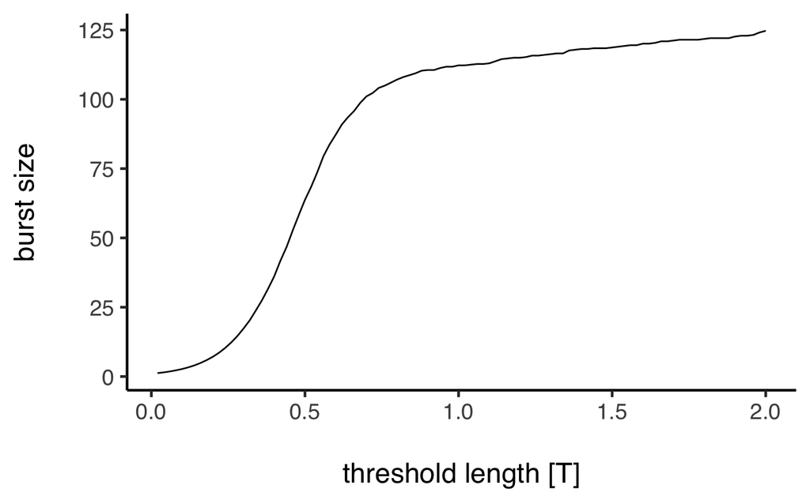

```r
ggplot(df.phi, aes(x=t, y=b)) +
  geom_line() +
  xlab("\nthreshold length [T]") +
  ylab("burst size\n") +
  myGGtheme
```

## Burst size

```r
tx = 0.8
f.inter = function(x) splinefun(df.phi$t, df.phi$b, method='monoH.FC')(x)
f.inter(tx)
```

```
[1] 107.1307
```

## Burst significance

```r
1 - f.inter(0.5)/f.inter(1.5)
```

```
[1] 0.462963
```

## Burst duration

τβ, is the mean inter-arrival time within a burst. Calculate by averaging over intervals lower than τX.

```r
mean(v.sub)
```

```
[1] 0.09878686
```

## Burstiness

See definition in https://arxiv.org/pdf/1604.01125.pdf

B has the value of −1 for regular time series as σ = 0, and 0 for Poissonian or random time series as σ = μ. Finally, the value of B approaches 1 for extremely bursty time series as σ → ∞ for finite μ.

```r
(sd(df$V1) - mean(df$V1))/(sd(df$V1) + mean(df$V1))
```

```
[1] 0.7489806
```